# Learning Lab 1 Case Study

Lexi Lishinski

July 13, 2022

First, please add your name above!

In the overview presentation for this learning lab, we considered five steps in our supervised machine learning process. Those steps are mirrored here in this case study—with the addition of a preamble step whereby we load and process the data. Our driving question is: Can we predict something we would have coded by hand?

We use the #NGSSchat data set as the context in which we answer this question. See the network analysis of #NGSSchat (Rosenberg et al., 2020) that used the coding frame from van Bommel et al. (2020) (available [here](https://github.com/laser-institute/essential-readings/blob/main/machine-learning/ml-lab-1/van-bommel-et-al-2020-tate.pdf)) for the transactional or substantive nature of social media-based conversations. Notably, Rosenberg et. al. coded *a lot* of data by hand, and it would be quite convenient if the coding could be automated through supervised machine learning methods. Though this case study is tied to the #NGSSchat data, you can consider how qualitative coding you or colleagues have done could be automated in a similar manner. In short, again, can we predict something we would, heretofore, have coded by hand?

That paper - that presents the qualitative coding of a large number of tweets to the #NGSSchat - is available [here](https://github.com/laser-institute/essential-readings/blob/main/machine-learning/ml-lab-1/rosenberg-et-al-2020-jrst.pdf):

> Rosenberg, J. M., Reid, J. W., Dyer, E. B., Koehler, M. J., Fischer, C., & McKenna, T. J. (2020). Idle chatter or compelling conversation? The potential of the social media‐based# NGSSchat network for supporting science education reform efforts. Journal of Research in Science Teaching, 57(9), 1322-1355. [Link](https://github.com/laser-institute/essential-readings/blob/main/machine-learning/ml-lab-1/rosenberg-et-al-2020-jrst.pdf).

Conceptually, we focus on prediction and how it differs from the goals of description or explanation.

## Step 0: Loading and setting up

First, let’s load the packages we’ll use—the familiar {tidyverse} and several others focused on modeling. Like in earlier learning labs, click the green arrow to run the code chunk.

```r
library(tidyverse)
library(tidymodels)
library(janitor)
```

Next, we’ll load the *already-processed* (for this lab) data set that we’ll use for our supervised machine learning modeling.

*Note*: We created a means of visualizing the threads to make coding them easier; that’s here and it provides a means of seeing what the raw data is like: https://jmichaelrosenberg.shinyapps.io/ngsschat-shiny/

```r
d <- read_csv("data/ngsschat-processed-data.csv")

d
```

```
## # A tibble: 3,793 × 5
##    mean_favorite_count mean_retweet_count sum_display_text_width     n code
##                  <dbl>              <dbl>                  <dbl> <dbl> <chr>
##  1               1                  0                        214     2 TS
##  2               0                  0                         76     2 TS
##  3               0.125              0                       1689    16 SB
##  4               0.5                0                        217     2 TS
##  5               0.5                0                        143     2 TS
##  6               0.667              0.333                    376     3 TS
##  7               2                  0                        115     2 TS
##  8               1.5                0                        298     4 TS
##  9               3                  0                        233     2 TS
## 10               0.5                0                         98     2 TS
## # … with 3,783 more rows
```

The data has only five variables:

Your Turn ⤵

In the chunk below, examine the prepared data using a function or means of your choice (such as just *printing* the data set by typing its name or using the `glimpse()` function). Do this in the code chunk below! Note its dimensions — especially how many rows it has. Add a few dashes after the chunk with your observations.

```r
d
```

```
## # A tibble: 3,793 × 5
##    mean_favorite_count mean_retweet_count sum_display_text_width     n code
##                  <dbl>              <dbl>                  <dbl> <dbl> <chr>
##  1               1                  0                        214     2 TS
##  2               0                  0                         76     2 TS
##  3               0.125              0                       1689    16 SB
##  4               0.5                0                        217     2 TS
##  5               0.5                0                        143     2 TS
##  6               0.667              0.333                    376     3 TS
##  7               2                  0                        115     2 TS
##  8               1.5                0                        298     4 TS
##  9               3                  0                        233     2 TS
## 10               0.5                0                         98     2 TS
## # … with 3,783 more rows
```

*Observations*:

- code is character variable with 2 categories
- The other variables are numeric

*What other variables might we include?** This is a great question to be asking - surely, including just the four variables we have cannot be *that* predictive (right?)! Let’s use these few, relatively simple variables for now, but know that we’ll use far more variables when we get to the third learning lab.

## Step 1. Split data

- The *training set* is used to estimate develop and compare models, feature engineering techniques, tune models, etc.
- The *test set* is held in reserve until the end of the project, at which point there should only be one or two models under serious consideration. It is used as an unbiased source for measuring final model performance.

There are different ways to create these partitions of the data and there is no uniform guideline for determining how much data should be set aside for testing. The proportion of data can be driven by many factors, including the size of the original pool of samples and the total number of predictors.

Here, we split the data. We do so using our first {tidymodels} function - `initial_split()`.

It is common when beginning a modeling project to [separate the data set](https://bookdown.org/max/FES/data-splitting.html) into two partitions. Why do we choose an 80% split (see `prop = .80` below)

This is to reserve a sufficient number of cases for testing our fitted model later. You can change this number if you wish.

Additionally, since random sampling uses random numbers, it is important to set the random number seed. This ensures that the random numbers can be reproduced at a later time (if needed). We pick the first date on which we may carry out this learning lab as the seed, but any number will work!

The function `initial_split()` function from the {rsample} package takes the original data and saves the information on how to make the partitions. The {rsample} package has two aptly named functions for created a training and testing data set called `training()` and `testing()`, respectively.

Run the following code to split the data:

```r
set.seed(20220712)
train_test_split <- initial_split(d, prop = .80)
data_train <- training(train_test_split)
```

Go ahead and type `data_train` and `d` into the console (in steps) to check that this data set indeed has 80% of the number of observations as in the larger data. Do that in the chunk below:

Your Turn ⤵

```r
d
```

```
## # A tibble: 3,793 × 5
##    mean_favorite_count mean_retweet_count sum_display_text_width     n code
##                  <dbl>              <dbl>                  <dbl> <dbl> <chr>
##  1               1                  0                        214     2 TS
##  2               0                  0                         76     2 TS
##  3               0.125              0                       1689    16 SB
##  4               0.5                0                        217     2 TS
##  5               0.5                0                        143     2 TS
##  6               0.667              0.333                    376     3 TS
##  7               2                  0                        115     2 TS
##  8               1.5                0                        298     4 TS
##  9               3                  0                        233     2 TS
## 10               0.5                0                         98     2 TS
## # … with 3,783 more rows
```

```r
data_train
```

```
## # A tibble: 3,034 × 5
##    mean_favorite_count mean_retweet_count sum_display_text_width     n code
##                  <dbl>              <dbl>                  <dbl> <dbl> <chr>
##  1                2                  0.8                     563     5 SB
##  2                1                  0                       121     1 TS
##  3                0                  0                       206     2 SB
##  4                1.5                0                        98     2 TS
##  5                0.5                0                       237     2 TS
##  6                6.5                5.25                    330     4 SB
##  7                0                  0                       110     1 TS
##  8                0.75               0                       421     4 SB
##  9                3.5                2                       227     2 SB
## 10                2.75               1.25                    468     4 SB
## # … with 3,024 more rows
```

3793 observations vs 3034 in the training set

## Step 2: Engineer features and write down the recipe

We’ll engage in a very basic feature engineering step, though we’ll do this *much* more in the next learning lab. Read more about feature engineering [here](https://www.tmwr.org/recipes.html).

To do feature engineering, we introduce another {tidymodels} package, [recipes](https://recipes.tidymodels.org/), which is designed to help you prepare your data *before* training your model - in other words, to engage in *feature engineering*. That’s all we’ll say about this now; we’ll dive into feature engineering in the third learning lab. For now, we’ll just use the variables as they are – we’ll do *no* feature engineering at this stage.

To get started, let’s create a recipe for a simple logistic regression model. Before training the model, we can use a recipe.

The [`recipe()`function](https://recipes.tidymodels.org/reference/recipe.html) as we used it here has two arguments:

- A **formula**. Any variable on the left-hand side of the tilde (`~`) is considered the model outcome (`code`, in our present case). On the right-hand side of the tilde are the predictors. Variables may be listed by name, or you can use the dot (`.`) to indicate all other variables as predictors.
- The **data**. A recipe is associated with the data set used to create the model. This will typically be the *training* set, so `data = train_data` here. Naming a data set doesn’t actually change the data itself; it is only used to catalog the names of the variables and their types, like factors, integers, dates, etc.

```r
my_rec <- recipe(code ~ ., data = data_train)
```

## Step 3: Specify the model and workflow

Next, we specify the model - using the `logistic_reg()` function to set the *model* - using `set_engine("glm")` to set the *engine* - finally, using `set_mode("classification"))` to set the “*mode*” to classification; this could be changed to regression for a continuous/numeric outcome:

```r
# specify model
my_mod <-
    logistic_reg() %>%
    set_engine("glm") %>%
    set_mode("classification")
```

## Step 4: Fit model

We will want to use our recipes created earlier across several steps as we train and test our model. To simplify this process, we can use a *model workflow*, which pairs a model and recipe together.

This is a straightforward approach because different recipes are often needed for different models, so when a model and recipe are bundled, it becomes easier to train and test *workflows*.

So, last, we’ll put the pieces together - the model and recipe.

We’ll use the {[workflows](https://workflows.tidymodels.org/)} package from tidymodels to bundle our parsnip model (`my_mod`) with our first recipe (`my_rec`).

```r
my_wf <-
    workflow() %>%
    add_model(my_mod) %>%
    add_recipe(my_rec)
```

Finally, we’ll fit our model.

```r
fitted_model <- fit(my_wf, data = data_train)
```

Your Turn ⤵

Type `final_fit` below; this is the final, fitted model—one that can be interpreted further in the next step!

```r
final_fit
```

```
## # Resampling results
## # Manual resampling
## # A tibble: 1 × 6
##   splits             id               .metrics .notes   .predictions .workflow
##   <list>             <chr>            <list>   <list>   <list>       <list>
## 1 <split [3034/759]> train/test split <tibble> <tibble> <tibble>     <workflow>
##
## There were issues with some computations:
##
##   - Warning(s) x1: glm.fit: fitted probabilities numerically 0 or 1 occurred
##
## Run `show_notes(.Last.tune.result)` for more information.
```

You may see a message/warning above or when you examine `final_fit`; you can safely ignore that.

## Step 5: Interpret accuracy

Run the code below to examine the predictions for the *test* split of data. Note that the row ID is in the output below, but this doesn’t correspond one-one to the ID variables used in the presentation/Shiny.

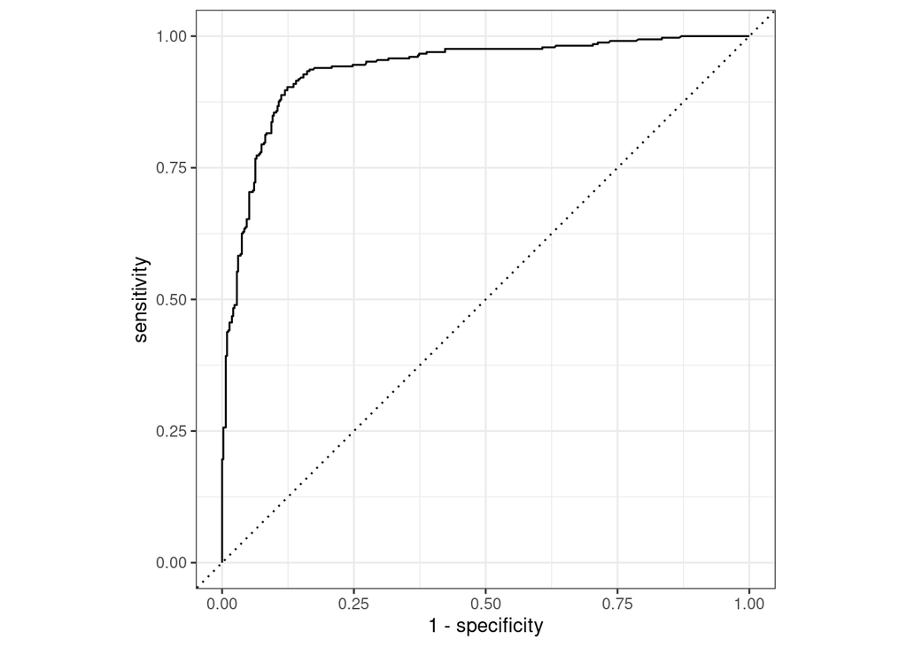

```r
# collect test split predictions
preds <- final_fit %>%
    collect_predictions() %>%
     mutate(correct = .pred_class == code)

preds %>% roc_curve(code, .pred_SB) %>% autoplot()
```

This is our first set of real output! Note two things:

1. `.pres_class`: This is the *predicted* code
2. `code`: This is the known *code*

When these are **the same**, the model predicted the code *correctly*; when they aren’t the same, the model was incorrect.

Importantly, we can *summarize* across all of these codes. One way to do this is straightforward; how many of the codes were the same, as in the following chunk of code:

```r
final_fit %>%
    collect_predictions() %>% # see test set predictions
    select(.pred_class, code) %>% # just to make the output easier to view
    mutate(correct = .pred_class == code) # create a new variable, correct, telling us when the model was and was not correct
```

```
## # A tibble: 759 × 3
##    .pred_class code  correct
##    <fct>       <fct> <lgl>
##  1 SB          TS    FALSE
##  2 SB          TS    FALSE
##  3 TS          TS    TRUE
##  4 SB          TS    FALSE
##  5 SB          TS    FALSE
##  6 SB          SB    TRUE
##  7 SB          SB    TRUE
##  8 SB          SB    TRUE
##  9 SB          SB    TRUE
## 10 SB          SB    TRUE
## # … with 749 more rows
```

That’s helpful, but there’s one more step we can take – counting up the values of `correct`:

```r
final_fit %>%
    collect_predictions() %>% # see test set predictions
    select(.pred_class, code) %>% # just to make the output easier to view
    mutate(correct = .pred_class == code) %>% # create a new variable, correct, telling us when the model was and was not correct
    tabyl(correct)
```

```
##  correct   n   percent
##    FALSE  99 0.1304348
##     TRUE 660 0.8695652
```

```r
final_fit$.predictions[[1]] %>%
     conf_mat(.pred_class, code)
```

```
##           Truth
## Prediction  SB  TS
##         SB 272  59
##         TS  40 388
```

Let’s interpret the above. If the value of `correct` is `TRUE` when the predicted and known code are the same, what does the `percent` column tell us? Add one or more notes to the dashes below:

- The percent of rows in the test set that did not match and did match between their predicted and and actual code.

A short-cut to the above is below:

```r
final_fit %>%
    collect_metrics()
```

```
## # A tibble: 2 × 4
##   .metric  .estimator .estimate .config
##   <chr>    <chr>          <dbl> <chr>
## 1 accuracy binary         0.870 Preprocessor1_Model1
## 2 roc_auc  binary         0.937 Preprocessor1_Model1
```

**Observations**

That’s it for now; the core parts of machine learning are used in the above steps you took; what we’ll do after this leaning lab only adds nuance and complexity to what we’ve already done.

## 🧶 Knit & Check ✅

Congratulations - you’ve completed this case study! Consider moving on to the badge activity next.